# DA5030 Decision Trees

Larkin, Yvonne

## Q1 Set-up R Project

```r
library(knitr) # kable
library(ggplot2) # Q3
library(caret) # Q4
library(rpart) # Q5
library(rpart.plot) # Q6
library(C50) # Q9
```

## Q2 Load CSV File

```r
# load local file by name
df <- read.csv2(file = "bank-term-deposit-marketing-full.csv",
                header = TRUE,
                stringsAsFactors = TRUE)
# print header to check it loaded
head(df, 5)
```

|  | age | job | marital | education | default | balance | housing | loan | contact | day | month | duration | campaign | pdays | previous | poutcome | y |
| --- | --- | --- | --- | --- | --- | --- | --- | --- | --- | --- | --- | --- | --- | --- | --- | --- | --- |
| 1 | 58 | management | married | tertiary | no | 2143 | yes | no | unknown | 5 | may | 261 | 1 | -1 | 0 | unknown | no |
| 2 | 44 | technician | single | secondary | no | 29 | yes | no | unknown | 5 | may | 151 | 1 | -1 | 0 | unknown | no |
| 3 | 33 | entrepreneur | married | secondary | no | 2 | yes | yes | unknown | 5 | may | 76 | 1 | -1 | 0 | unknown | no |
| 4 | 47 | blue-collar | married | unknown | no | 1506 | yes | no | unknown | 5 | may | 92 | 1 | -1 | 0 | unknown | no |
| 5 | 33 | unknown | single | unknown | no | 1 | no | no | unknown | 5 | may | 198 | 1 | -1 | 0 | unknown | no |

## Q3 Data Exploration

```r
str(df)
```

```
## 'data.frame':    45211 obs. of  17 variables:
##  $ age      : int  58 44 33 47 33 35 28 42 58 43 ...
##  $ job      : Factor w/ 12 levels "admin.","blue-collar",..: 5 10 3 2 12 5 5 3 6 10 ...
##  $ marital  : Factor w/ 3 levels "divorced","married",..: 2 3 2 2 3 2 3 1 2 3 ...
##  $ education: Factor w/ 4 levels "primary","secondary",..: 3 2 2 4 4 3 3 3 1 2 ...
##  $ default  : Factor w/ 2 levels "no","yes": 1 1 1 1 1 1 1 2 1 1 ...
##  $ balance  : int  2143 29 2 1506 1 231 447 2 121 593 ...
##  $ housing  : Factor w/ 2 levels "no","yes": 2 2 2 2 1 2 2 2 2 2 ...
##  $ loan     : Factor w/ 2 levels "no","yes": 1 1 2 1 1 1 2 1 1 1 ...
##  $ contact  : Factor w/ 3 levels "cellular","telephone",..: 3 3 3 3 3 3 3 3 3 3 ...
##  $ day      : int  5 5 5 5 5 5 5 5 5 5 ...
##  $ month    : Factor w/ 12 levels "apr","aug","dec",..: 9 9 9 9 9 9 9 9 9 9 ...
##  $ duration : int  261 151 76 92 198 139 217 380 50 55 ...
##  $ campaign : int  1 1 1 1 1 1 1 1 1 1 ...
##  $ pdays    : int  -1 -1 -1 -1 -1 -1 -1 -1 -1 -1 ...
##  $ previous : int  0 0 0 0 0 0 0 0 0 0 ...
##  $ poutcome : Factor w/ 4 levels "failure","other",..: 4 4 4 4 4 4 4 4 4 4 ...
##  $ y        : Factor w/ 2 levels "no","yes": 1 1 1 1 1 1 1 1 1 1 ...
```

```r
summary(df)
```

```
##       age                 job           marital          education
##  Min.   :18.00   blue-collar:9732   divorced: 5207   primary  : 6851
##  1st Qu.:33.00   management :9458   married :27214   secondary:23202
##  Median :39.00   technician :7597   single  :12790   tertiary :13301
##  Mean   :40.94   admin.     :5171                    unknown  : 1857
##  3rd Qu.:48.00   services   :4154
##  Max.   :95.00   retired    :2264
##                  (Other)    :6835
##  default        balance       housing      loan            contact
##  no :44396   Min.   : -8019   no :20081   no :37967   cellular :29285
##  yes:  815   1st Qu.:    72   yes:25130   yes: 7244   telephone: 2906
##              Median :   448                           unknown  :13020
##              Mean   :  1362
##              3rd Qu.:  1428
##              Max.   :102127
##
##       day            month          duration         campaign
##  Min.   : 1.00   may    :13766   Min.   :   0.0   Min.   : 1.000
##  1st Qu.: 8.00   jul    : 6895   1st Qu.: 103.0   1st Qu.: 1.000
##  Median :16.00   aug    : 6247   Median : 180.0   Median : 2.000
##  Mean   :15.81   jun    : 5341   Mean   : 258.2   Mean   : 2.764
##  3rd Qu.:21.00   nov    : 3970   3rd Qu.: 319.0   3rd Qu.: 3.000
##  Max.   :31.00   apr    : 2932   Max.   :4918.0   Max.   :63.000
##                  (Other): 6060
##      pdays          previous           poutcome       y
##  Min.   : -1.0   Min.   :  0.0000   failure: 4901   no :39922
##  1st Qu.: -1.0   1st Qu.:  0.0000   other  : 1840   yes: 5289
##  Median : -1.0   Median :  0.0000   success: 1511
##  Mean   : 40.2   Mean   :  0.5803   unknown:36959
##  3rd Qu.: -1.0   3rd Qu.:  0.0000
##  Max.   :871.0   Max.   :275.0000
##
```

```r
# broad search for any missing values, none
missing_val <- ifelse(any(is.na(df)) == FALSE, "There are no Missing Values `NA` found in the `df` features.", "Missing Values found in `df`")
```

```r
# exploration due to str and summary outputs
neg_pdays <- length(which(df$pdays == -1)) # 36954 (-1)
prop_neg_val_pdays <-  round(neg_pdays/nrow(df), 3) # proportion -1
pdays_and_y_no <- which(df$pdays == -1 & df$y == "no") # 33570 (no&-1)
diff_pdays_y <- length(neg_pdays) - length(pdays_and_y_no) # 3384 [-1 - (no&-1)]

pout_unk <- length(which(df$poutcome == "unknown")) # 36959 (unknown)
pday_pout_comp <- length(which(df$pdays == -1 & df$poutcome == "unknown")) # 36954 (unknown&-1)
diff_pout_pday <- pout_unk -neg_pdays # 5 [unknown - (-1)]

pout_and_y <- length(which(df$y == "no" & df$poutcome == "unknown")) # 33573 (y&no)
diff_y_pout <- length(which(df$y == "no")) - pout_and_y # 6349 [no - (no&unknown)]
```

```r
#initialize count and
count <- 0
x <- vector("numeric", length = ncol(df))
for(i in 1:ncol(df)){
  if(is.integer(df[,i])){
    x[i] <- length(unique(df[[i]]))
    count <- (count + 1)
  } else {
    x[i] <- NA
    count <- count
  }
  x
  count
}
# variables for dynamic markdown
int_feat <- which(!is.na(x))
int_feat_name <- colnames(df)[int_feat]
non_factor <- data.frame(Feature = int_feat_name,
                         Unique_Values = x[int_feat])
```

### General Impressions

Download file to project and load by file name, name unchanged from downloaded name suggestion. Data is a semi-colon (;) delimited csv file for `read.csv2( )` is the default implementation for `sep = ";"` with 17 columns and 45211 row observations. There is a mixture of numeric and character features, loaded the data where `stringAsFactor = TRUE` since `factor` values are needed for model generation and Decision Tree Use.

**Target variable is “y”** and indicates whether the customer subscribed to a term deposit product offered by the bank, levels are : **no, yes**. Of the 7 `integer` features, 4 features have less than 100 unique values, however most numeric values are expansive enough that *discretization* doesn’t seem beneficial; especially since Decision Trees can handle both types of features.

Based on the `str( )` and `summary( )` outputs there does seem to be an imbalance in many of the features, where there is an apparent strong correlation between some parameters, like “poutcome” and “pdays” even when compared to the target “y” for “no” subscription. Graphing the data will give a better distribution overview. Regardless of the distribution though, Decision Trees can work with either p”parametric” or “non-parametric” data.

### Q3 Missing Values

**There are no Missing Values `NA` found in the `df` features.**  
Thankfully no missing values need to be handled in this dataset, I say this because there are 7 numeric features and 10 factor features, so depending on the column a missing value is it would likely need more advanced techniques (models) to impute an appropriate value for it. It is likely that modeling techniques would be sufficient to predict a value. Numeric values could use kNN or Linear Regression (again due to the apparent high correlation of features) and categorical features could use Naive Bayes. I don’t think more advanced techniques like deep learning etc would be needed (especially since we haven’t covered those in the course), but I do not believe a mean/median/mode approach would be sufficient. There is the potential for pairwise deletion in calculation. But overall Decision Trees and C5.0 specifically are not highly sensitive to missing values so if it we only a few *Missing Completely at Random Values* (MCAR) then I think it would be fine to not address them at all when proceeding with the Decision Tree Creation.

### Q3 Numeric Feature Histograms (Density/Proportion)

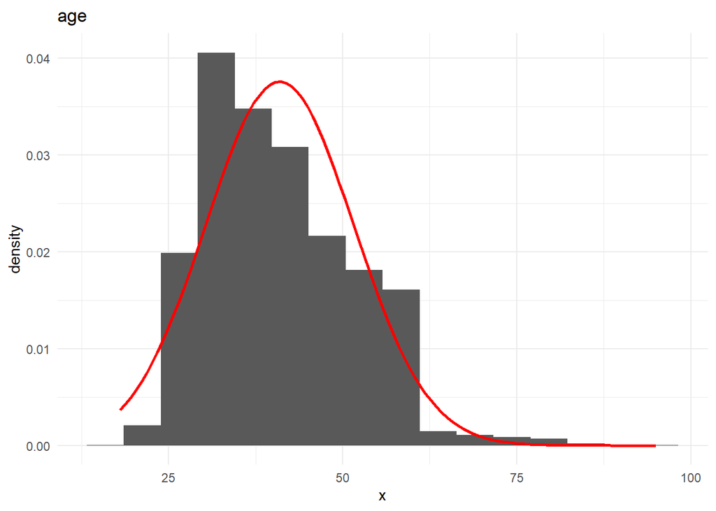

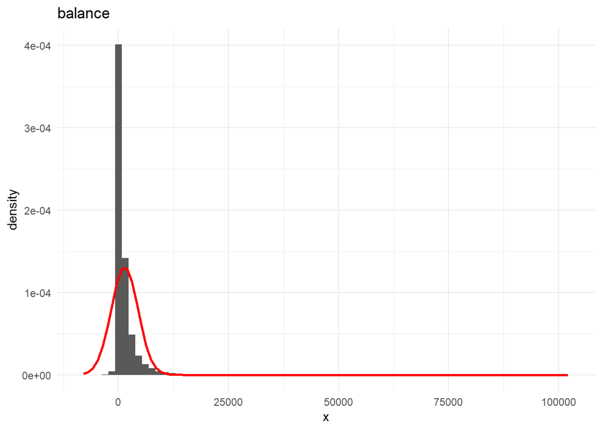

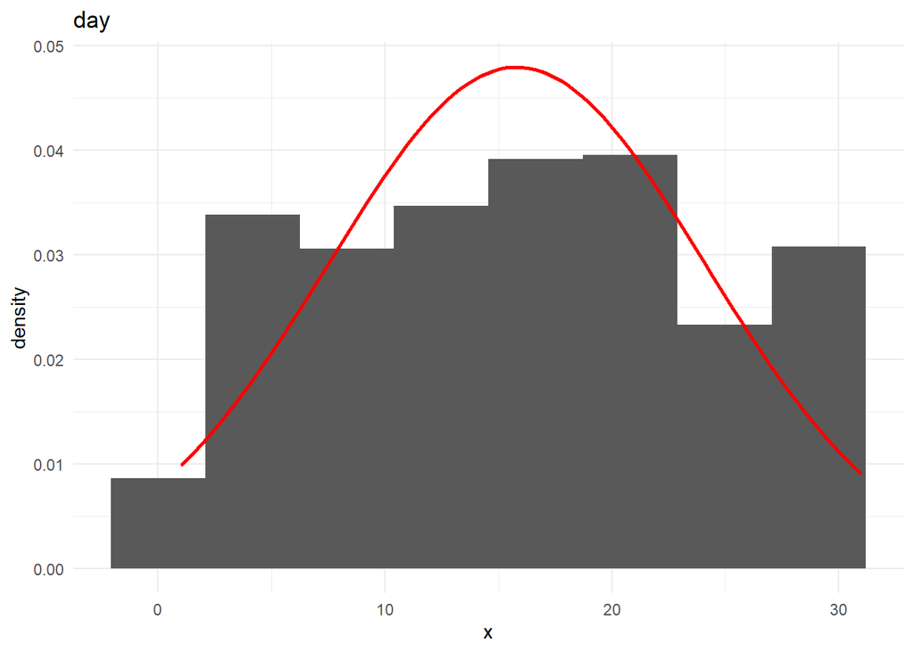

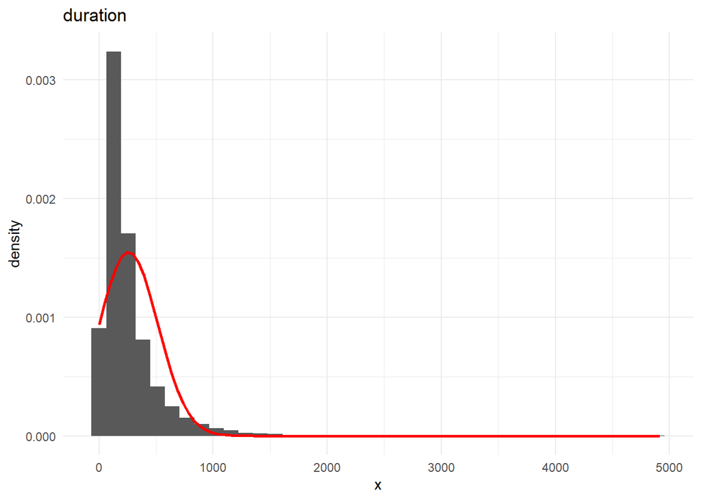

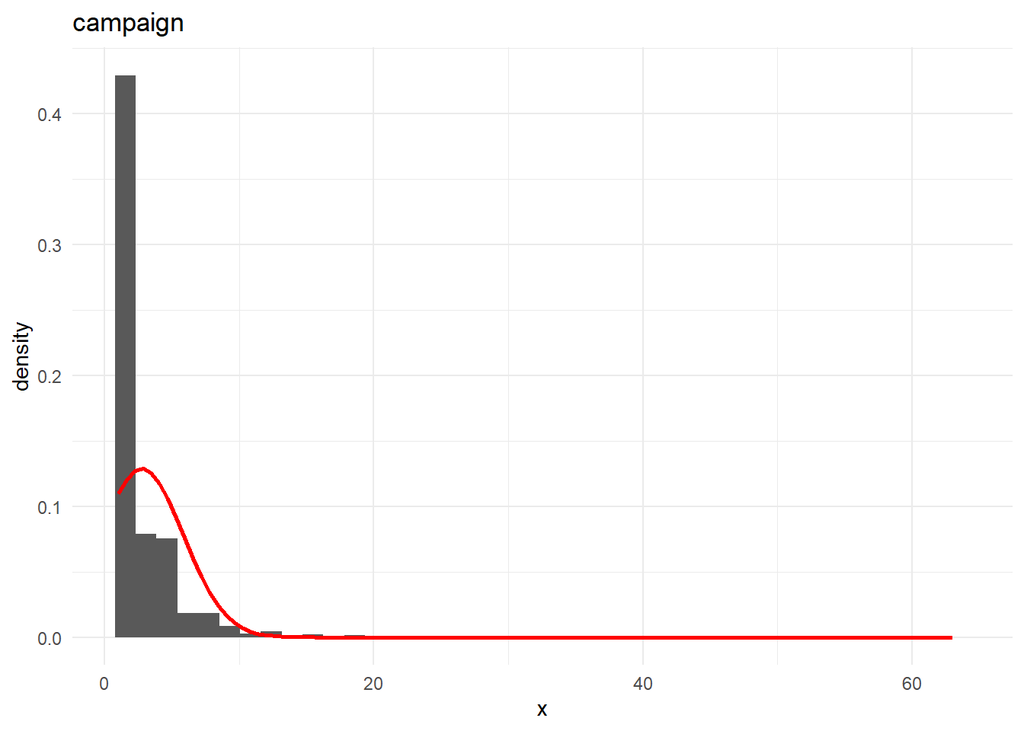

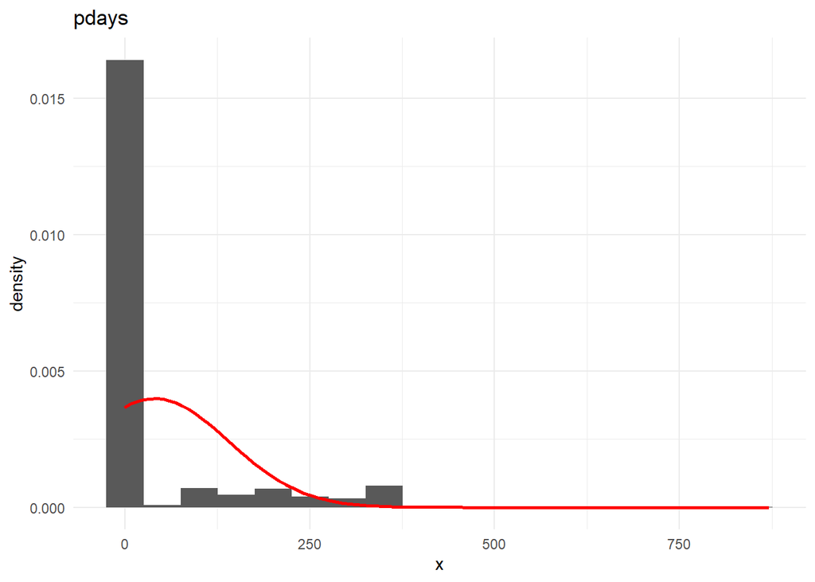

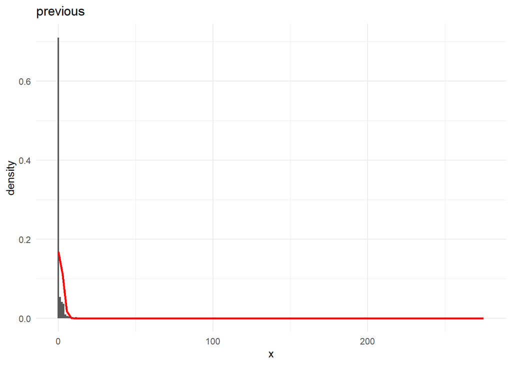

```r
# to compare data to a normal distribution need to use densities/probabilities not frequencies
for (i in int_feat) {
  # data column
  num_feat <- df[[i]]
  # numeric plotting with ggplot2 T.T
  np <- ggplot(data.frame(x = num_feat),
              aes(x)) +
    # set bin width to half the sd value of the feature so it is easier to visualize empirical rule
    geom_histogram(aes(y = ..density..),
                   binwidth = sd(num_feat)/2) +
    stat_function(fun = dnorm,
                  args = list(mean = mean(num_feat), sd = sd(num_feat)),
                  color = "red",
                  size = 1) +
    ggtitle(colnames(df)[i]) +
    theme_minimal()

  print(np)
}
```

```r
# citations at end of all graphs
```

### Q3 Categorical Feature Barplots (Frequency)

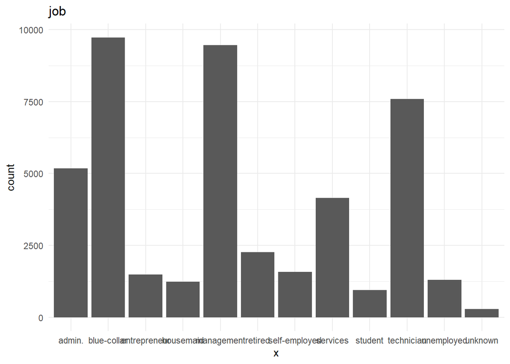

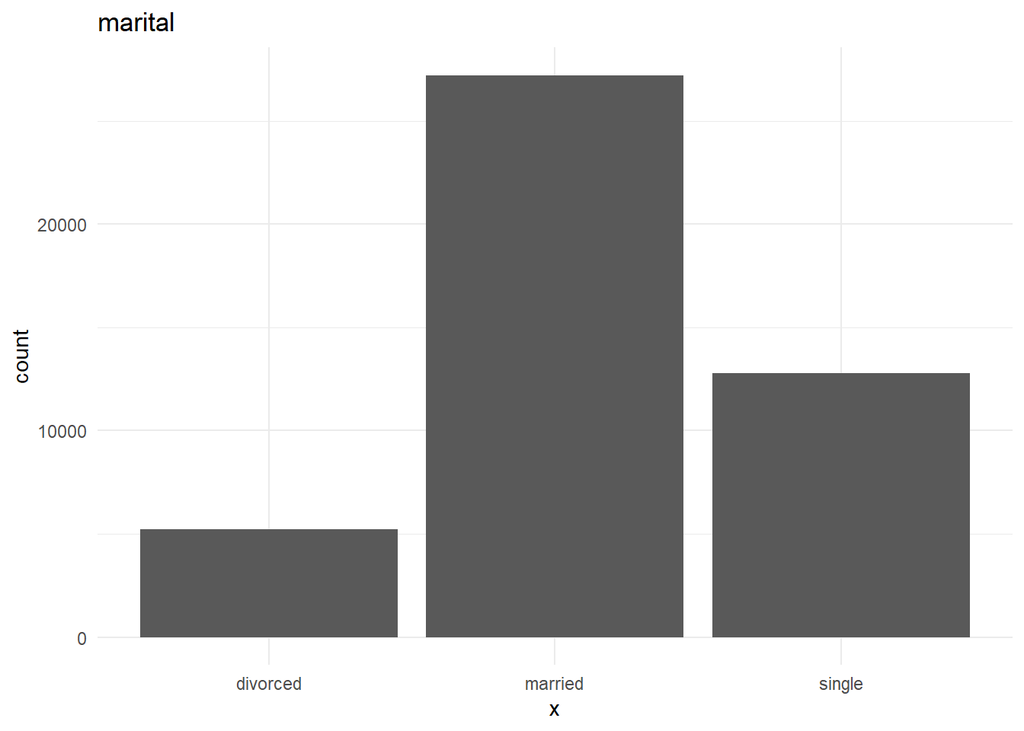

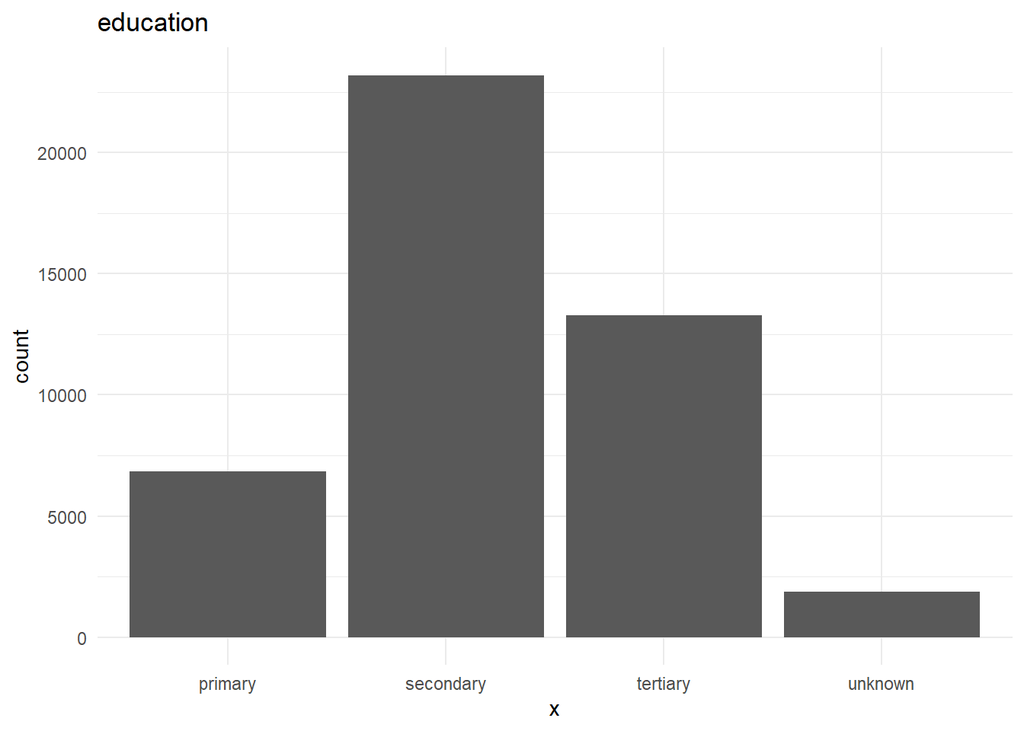

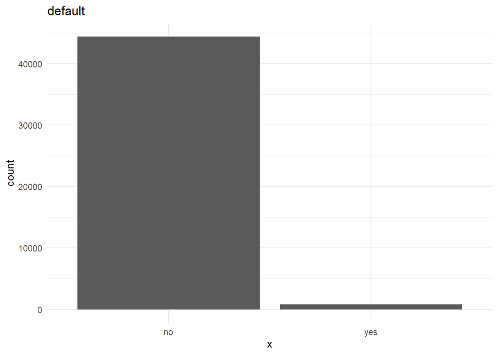

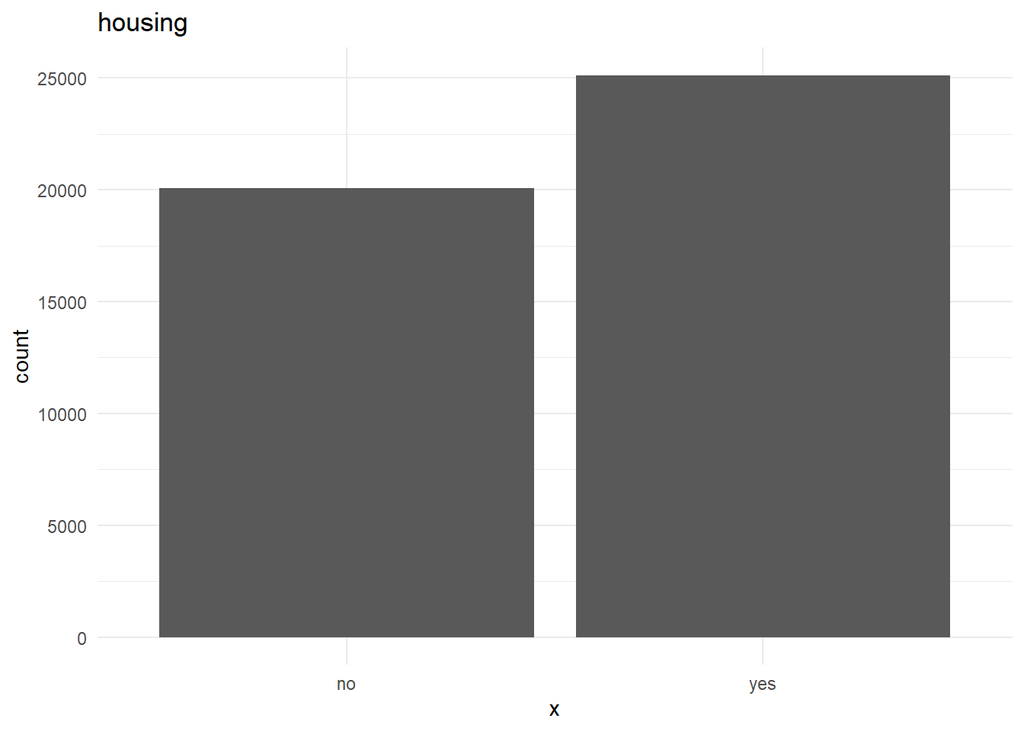

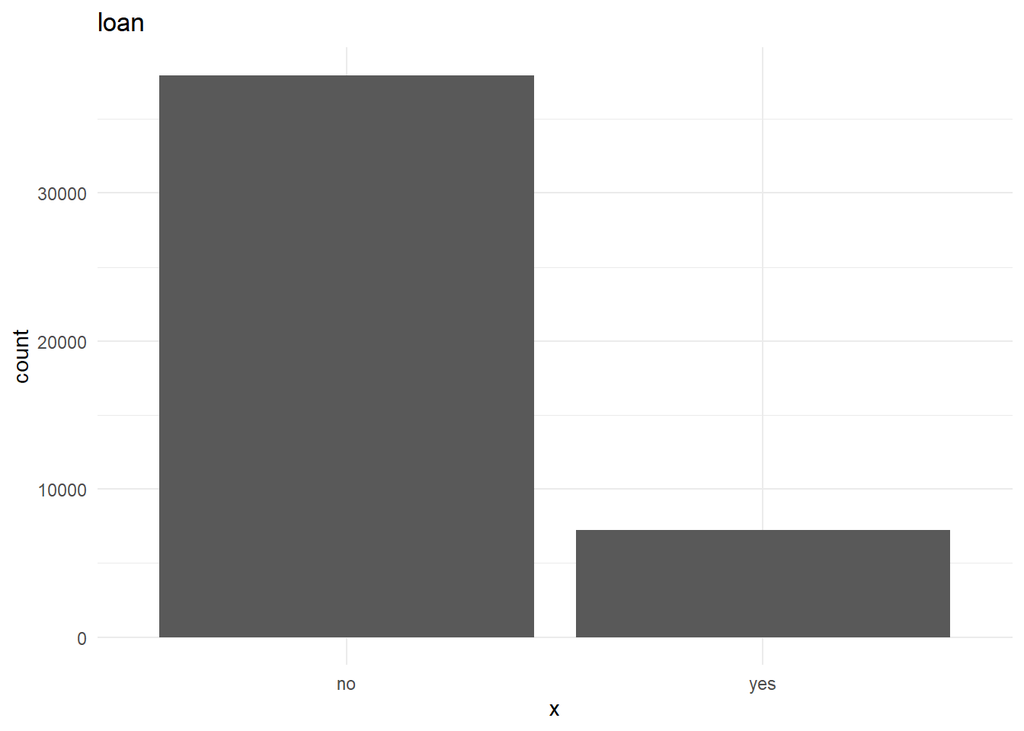

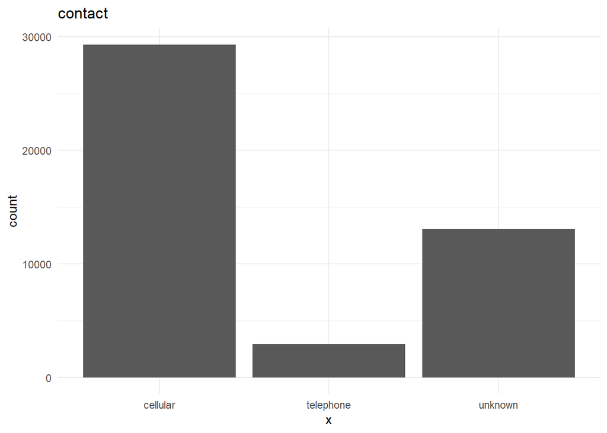

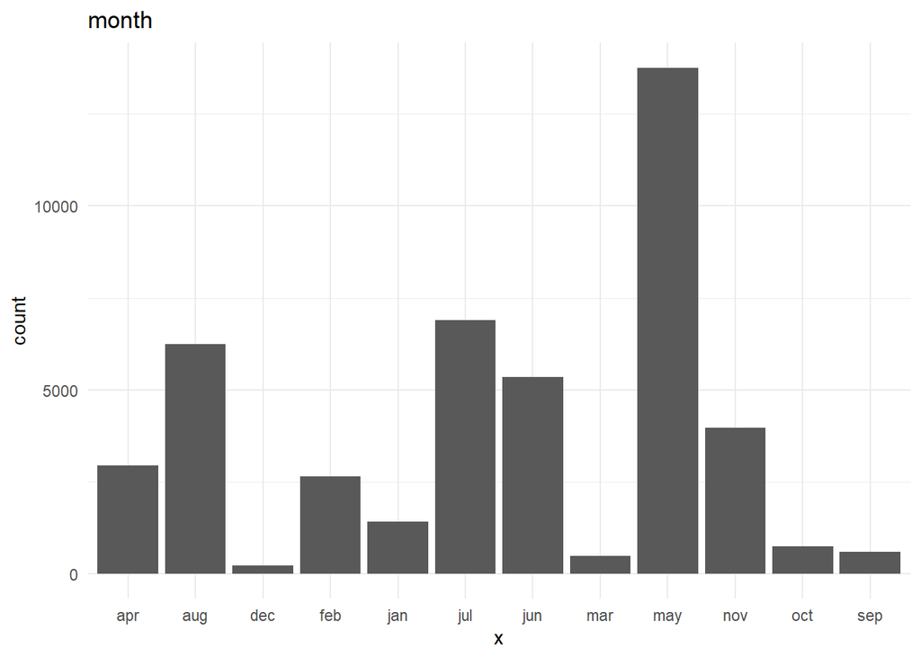

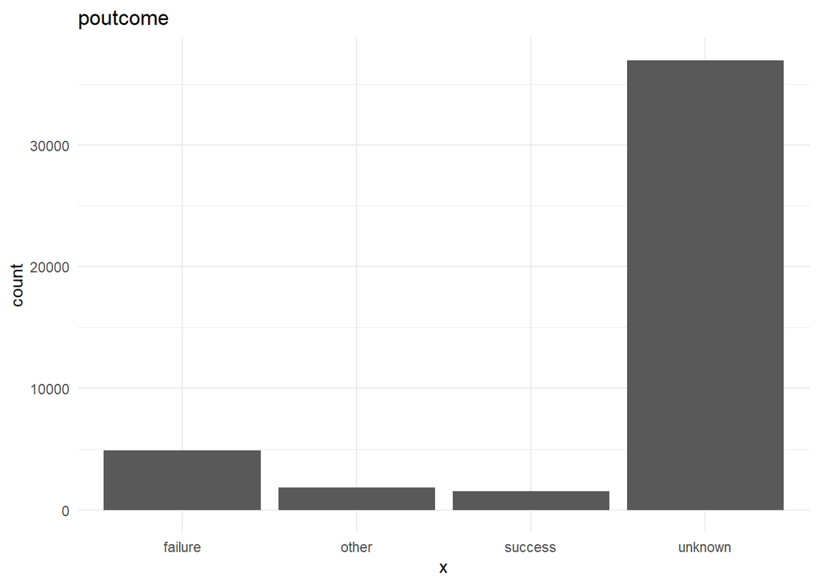

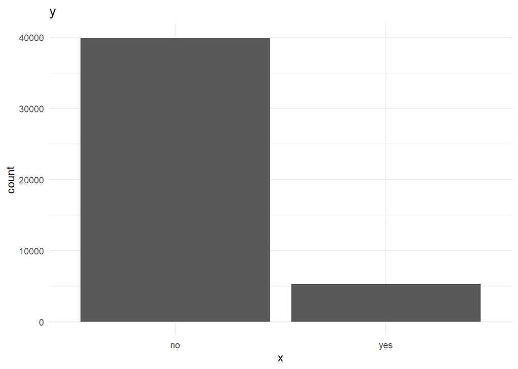

```r
# sub-dataframe of only categorical features
cat_feat <- df[,-int_feat]
for(i in 1:ncol(cat_feat)){
  # data column
  num_feat <- cat_feat[[i]]
  # categorical plotting with ggplot2 T.T
  cp <- ggplot(data.frame(x = num_feat),
              aes(x)) +
    # now looking at frequencies for each category, for discrete values (bins) so bar graph
    geom_bar()+
    ggtitle(colnames(cat_feat)[i]) +
    theme_minimal()

  print(cp)
}
```

```r
# citations at end of all graphs
```

Looking at the proportions this way is way faster than all of the `which()` search counts and comparisons, granted the `which()` searches allow for `&` operand to link features versus just looking at majority categorization but this is initial exploration so even linking isn’t concrete and a linear regression model would be more appropriate to evaluate and correlations, or at least `cor.test()`.

But it does **display multiple imbalances** in the categorical distributions, especially for the target value “y”, so this means splitting the data must take cross validation into account because while Decision Trees can deal with imbalances in data to some degree, if the training data does not have a feature criterion present then it would be used for decision node splits, feature split rank evaluation, and so could overlook an important sub-categorization split meaning it could be miss classified due to default handling of the new category (majority class, alternate splits, or treated as a missing value).[^2]

Citation conversation a separate html doc linked because Copilot doesn’t share conversations like ChatGPT (apologies for not realizing sooner) : [^3]: initial understanding for histogram density use and dnorm ChatGPT https://share.google/aimode/ryXilfGgO6Abu338Z dnorm [^4]: ggplot2 cheatsheet, since I never remember how to use ggplot2 file:///E:/Computer%20remove%20before%20reset/Documents/Northeastern%20Documents/ggplot2_Rvisualization_cheatsheet.pdf [^5]: (‘aes() meaning/use’) https://m365.cloud.microsoft/chat/entity1-d870f6cd-4aa5-4d42-9626-ab690c041429/eyJpZCI6IlZYTmxjbFl4ZkdoMGRIQnpPaTh2YzNWaWMzUnl… [^6]: ..density.. for histogram density https://m365.cloud.microsoft/chat/entity1-d870f6cd-4aa5-4d42-9626-ab690c041429/eyJpZCI6IlZYTmxjbFl4ZkdoMGRIQnpPaTh2YzNWaWMzUnl…

## Q4 Splitting Data

```r
# set seed for repeatability of results
set.seed(7)
# caret function for 80:20 split
training_index <- createDataPartition(df$y,
                                      p = 0.8,
                                      list = FALSE)
# split data
training_set <- df[training_index,]
testing_set <- df[-training_index,]
```

```r
# make tables to print in markdown
target.train.prop <- kable(round(prop.table(table(training_set$y)),3), caption = "Training Data Set's Proportion of Categorical Factors")
target.test.prop <- kable(round(prop.table(table(testing_set$y)),3), caption = "Testing Data Set's Proportion of Categorical Factors")
```

```r
# initialize list object
object <- vector("list", length = ncol(cat_feat))
# loop categorical features to eval proportions
for(x in 1:ncol(cat_feat)){
  name <- colnames(cat_feat)[x]
  train.prop <- prop.table(table(cat_feat[training_index, x]))
  test.prop <- prop.table(table(cat_feat[-training_index, x]))
  # nested named list
  object[[x]] <- I(list(cat = name,
                        train = train.prop,
                        test = test.prop))
}
# printed object to look at all categories of nested list; removed for knit
```

`caret::createDataPartition` is the specified way to sample the data using an 80:20 split for percent of data in training versus testing sets. The function `createDataPartition( )` does not have a cross validation method parameter for performing the split and the C5.0 function to create the Decision Tree model does not have a cross validation parameter either so the best we can do is probability table to test proportions of the target variable because ideally the proportions will be nearly equivalent or at least not significantly different. I visually compared the proportion of all categorical features, and luckily all features are present in the training and testing data, and also have very similar proportion values. So training the Decision Tree shouldn’t be an issue.

### Target Variable `df$y` Proportions

Training Data Set’s Proportion of Categorical Factors

| Var1 | Freq |
| --- | --- |
| no | 0.883 |
| yes | 0.117 |

Testing Data Set’s Proportion of Categorical Factors

| Var1 | Freq |
| --- | --- |
| no | 0.883 |
| yes | 0.117 |

## Q5 `rpart` package Decision Tree Classifier and Gini Index

```r
# target variable is already factor
# used RHelp ; especially example for the parms = ; and 8.3 Classification trees p 150 - 160 : https://cran.r-project.org/doc/contrib/Krijnen-IntroBioInfStatistics.pdf
rpart_fit <- rpart(y ~.,
      data = df,
      subset = training_index, # p. 160
      parms = list(prior = c(0.8, 0.2),
                   split = "gini"),
      method = "class")
# only did base ask from Q5 really
rpart_fit
```

```
## n= 36170
##
## node), split, n, loss, yval, (yprob)
##       * denotes terminal node
##
##  1) root 36170 7234.00000 no (0.80000000 0.20000000)
##    2) duration< 472.5 31425 3911.00900 no (0.87096334 0.12903666)
##      4) poutcome=failure,other,unknown 30424 2863.17300 no (0.90096226 0.09903774)
##        8) month=apr,aug,feb,jan,jul,jun,may,nov 29286 2134.98700 no (0.92246746 0.07753254) *
##        9) month=dec,mar,oct,sep 1138  645.07580 yes (0.46973980 0.53026020)
##         18) duration< 129.5 370   80.33979 no (0.78460000 0.21540000) *
##         19) duration>=129.5 768  352.43610 yes (0.35233656 0.64766344) *
##      5) poutcome=success 1001  351.53010 yes (0.25120666 0.74879334) *
##    3) duration>=472.5 4745 2537.72100 yes (0.43300562 0.56699438)
##      6) duration< 647.5 2185 1075.18600 no (0.56731752 0.43268248)
##       12) poutcome=failure,other,unknown 2077  929.89040 no (0.59897718 0.40102282) *
##       13) poutcome=success 108   20.83812 yes (0.12543000 0.87457000) *
##      7) duration>=647.5 2560 1127.97700 yes (0.33413795 0.66586205) *
```

This section took a lot of trial and error to complete, including: referencing R Help window for “{rpart}” and “{rpart.plot}” definitions and examples, reading the CranR documentation on Classification Methods Chapter 8 [^7] , and “Plotting rpart trees with the rpart plot package” vignette [^8] linked in RHelp, the linked “rpart.object” page, the assignment Hints and explicit parameters given. Also lots of playing around with indexing the model to see what is actually returned.

## Q6 Visualize `rpart` Decision Tree

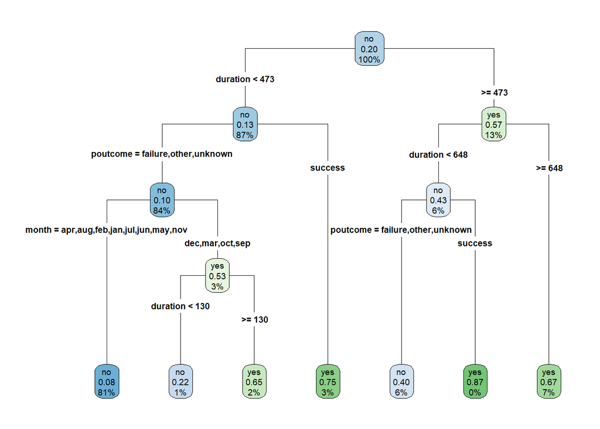

```r
# decision tree figure for rpart
test_predictions <- rpart.plot(rpart_fit,
                               type = 4)
```

*This was a really cool feature to learn about for the `rpart` package*

```r
# display the split order and rank
r_import_feat <- rpart_fit$variable.importance
```

The root node is the highest split/importance which is the feature duration 2141.14, 1196.55, 536.19, 12.62, 5.16, 3.19, 1.92, 0.85, 0.77

## Q7 Evaluate Validation data Set

```r
# make prediction
test_predict <- rpart.predict(rpart_fit,
              newdata = testing_set[,-which(names(testing_set) == "y")],
              type = "class")

# evaluate accuracy
r.AC <- confusionMatrix(test_predict, testing_set$y, positive = "yes")
r.AC
```

```
## Confusion Matrix and Statistics
##
##           Reference
## Prediction   no  yes
##        no  7496  474
##        yes  488  583
##
##                Accuracy : 0.8936
##                  95% CI : (0.8871, 0.8999)
##     No Information Rate : 0.8831
##     P-Value [Acc > NIR] : 0.0008727
##
##                   Kappa : 0.4876
##
##  Mcnemar's Test P-Value : 0.6751161
##
##             Sensitivity : 0.55156
##             Specificity : 0.93888
##          Pos Pred Value : 0.54435
##          Neg Pred Value : 0.94053
##              Prevalence : 0.11691
##          Detection Rate : 0.06448
##    Detection Prevalence : 0.11846
##       Balanced Accuracy : 0.74522
##
##        'Positive' Class : yes
##
```

## Q8 Hyperparameter “Complexity Parameter” (*cp*) and “maxdepth”

### pre-tuning “cp” “or maxDepth”

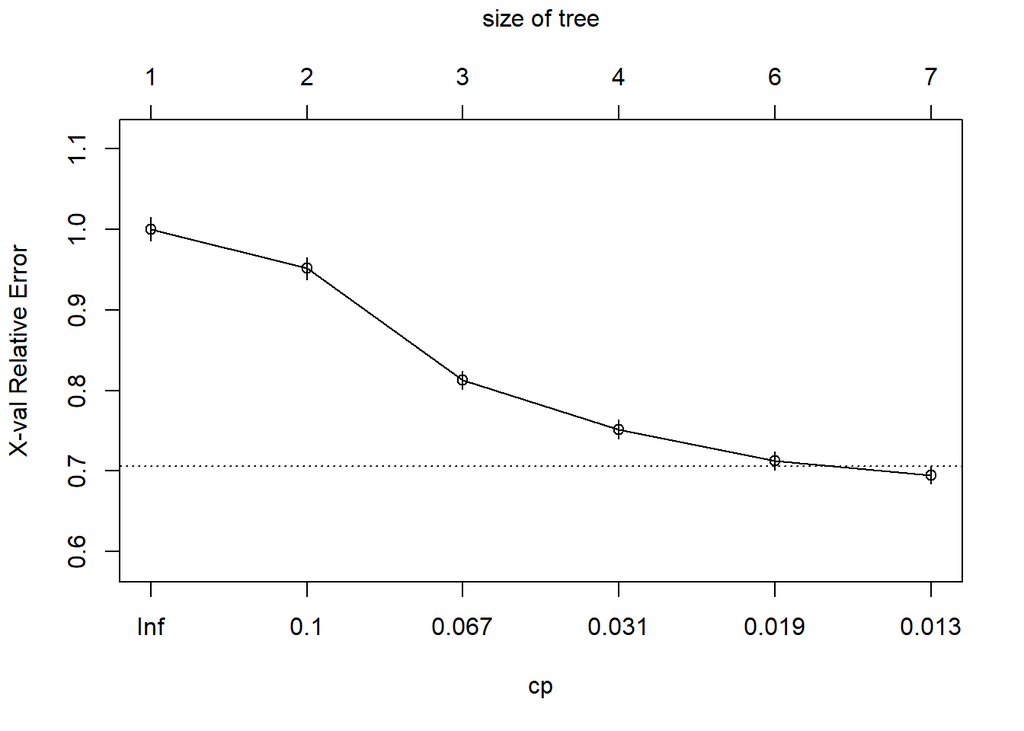

```r
# current cp values
pre.cp <- rpart_fit$cptable
plotcp(rpart_fit)
```

Based on the plot of the current `rpart` model I think raising the ‘cp’ value to “0.031” might be better or even the “0.019” where it begins to flatten out would be better. But I will check all plot values above the default `cp = 0.01` and not at decision tree size = 1 split could be interesting.

### Complexity Parameter(cp)

```r
# initialize data
cp_val <- c(0.1, 0.067,0.031, 0.019, 0.013)
cp_fit <- vector("list", length = length(cp_val))
name_cp <- vector("character", length = length(cp_val))

# loop models
for(i in 1: length(cp_val)){
  name_cp[i] <- paste("cp =", cp_val[i], collapse = " ")
  cp_fit[[i]] <- rpart(y ~.,
                     data = df,
                     subset = training_index,
                     parms = list(prior = c(0.8, 0.2),
                                  split = "gini"),
                     method = "class",
                     cp = cp_val[i])
}
```

### Complexity Parameter cross-validation error plots

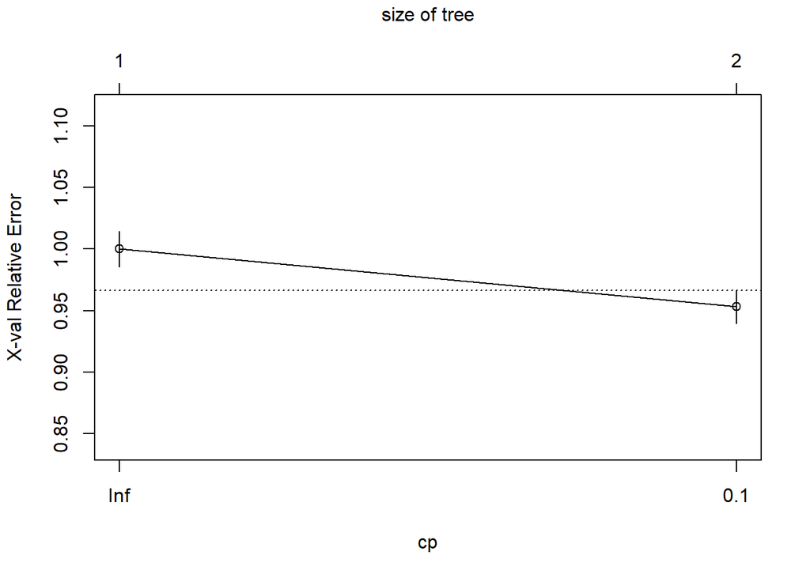

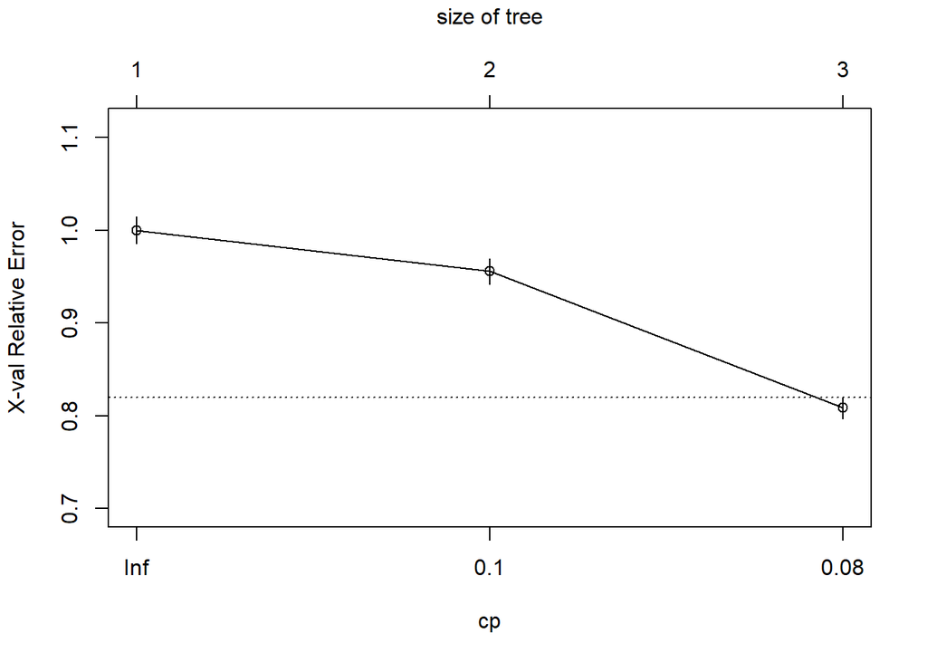

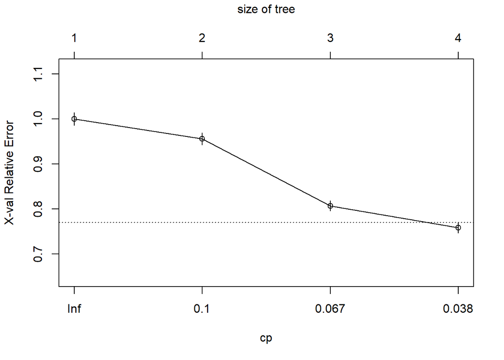

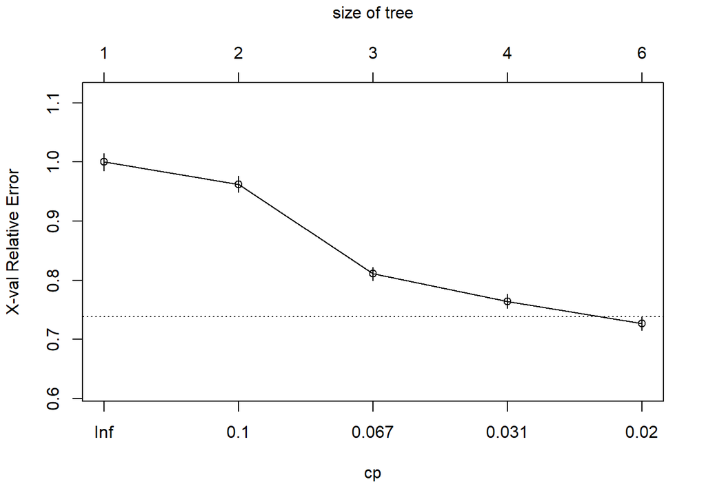

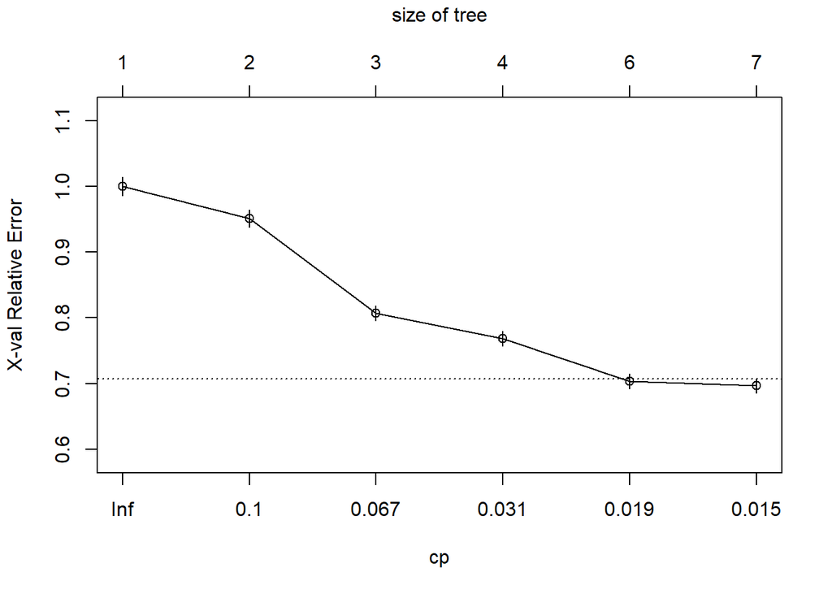

```r
# plot all cp ; for loop to avoid "NULL" plot with lapply()
for(i in 1:length(cp_fit)){
  plotcp(cp_fit[[i]])
}
```

### Q8 Extract Accuracy Values for cp models

```r
# initialize list
cp_confM <- vector("list", length = length(cp_fit))
for(i in 1:length(cp_fit)){
  preds <- rpart.predict(cp_fit[[i]],
                           newdata = testing_set[,-which(names(testing_set) == "y")],
                           type = "class")
  cp_confM[[i]] <- confusionMatrix(preds, testing_set$y, positive = "yes")
}
# df to print
cp.AC <- lapply(1:length(cp_fit), function(x){
  y <- cp_confM[[x]]
  y$overall['Accuracy']
  })
cp.kappa <- lapply(1:length(cp_fit), function(x){
  y <- cp_confM[[x]]
  y$overall['Kappa']
  })
cp.sens <- lapply(1:length(cp_fit), function(x){
  y <- cp_confM[[x]]
  y$byClass['Sensitivity']
  })
cp.spes <- lapply(1:length(cp_fit), function(x){
  y <- cp_confM[[x]]
  y$byClass['Specificity']
  })
cp.FP <- lapply(1:length(cp_fit), function(x){
  abs(cp.spes[[x]] - 1)
})
cp.FN <- lapply(1:length(cp_fit), function(x){
  abs(cp.sens[[x]] - 1)
})

cp.df <- data.frame(Model = name_cp,
                    Overall.Acc = unlist(cp.AC),
                    Kappa = unlist(cp.kappa),
                    TP_rate = unlist(cp.sens),
                    TN_rate = unlist(cp.spes),
                    FP_rate = unlist(cp.FP),
                    FN_rate = unlist(cp.FN))
```

### “maxDepth” Parameter

```r
# initialize data
depth_val <- c(2:17)
depth_fit <- vector("list", length = length(cp_val))
name_depth <- vector("character", length = length(depth_val))

# loop models
for(i in 1:length(depth_val)){
  name_depth[i] <- paste("depth =", depth_val[i], collapse = " ")
  depth_fit[[i]] <- rpart(y ~.,
                     data = df,
                     subset = training_index,
                     parms = list(prior = c(0.8, 0.2),
                                  split = "gini"),
                     method = "class",
                     control = rpart.control(maxdepth = i))
}
```